# Capsule 3 - Comprendre la droite de régression

MQT-2101 - Analyse et modélisation des données

## Pourquoi ça compte

Comment traduire une droite en une comparaison utile?

La direction compare deux budgets séparés de 1 000 $. La pente donne la différence de ventes moyennes estimée par le modèle.

## Objectifs de la capsule

- Lire le modèle linéaire simple.
- Interpréter la pente et l’ordonnée à l’origine.
- Comprendre le résidu et les moindres carrés.

## Le modèle et la moyenne

$$Y_i = \beta_0 + \beta_1 x_i + \varepsilon_i$$

$$\mathrm{E}(Y_i \mid x_i) = \beta_0 + \beta_1 x_i$$

$x_i$ : budget. $Y_i$ : ventes. $\varepsilon_i$ : écart aléatoire non observé.

## La droite estimée

$$\widehat{y}_i = \widehat{\beta}_0 + \widehat{\beta}_1 x_i$$

Pente estimée

Différence de ventes moyennes estimée pour 1 $ de budget supplémentaire.

Ordonnée à l’origine estimée

Ventes prédites lorsque le budget vaut 0 $.

## Une comparaison de 1 000 $

Pente estimée : 13,58 $ de ventes par dollar de budget.

Pour 1 000 $ de budget supplémentaire : environ 13 582 $ de ventes moyennes supplémentaires selon la droite.

Une association estimée dans ces données simulées.

## Le budget nul est hors de la plage observée

2 497 $

Budget minimal observé

8 857 $

Budget maximal observé

0 $

Extrapolation

L’ordonnée estimée vaut 29 922 $. Son interprétation à budget nul n’est pas appuyée par ces observations.

## Un résidu se calcule sur une observation

$$e_i = y_i - \widehat{y}_i$$

121 915 $

Ventes observées

108 888 $

Ventes prédites

+13 027 $

Résidu, après arrondi

Capitale-Nationale, janvier 2025. Budget : 5 814 $.

## Le résidu dans le graphique

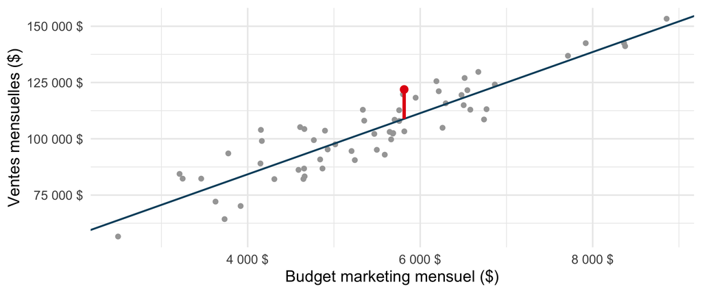

## Le principe des moindres carrés

$$\sum_{i=1}^{n} e_i^2 = \sum_{i=1}^{n}(y_i-\widehat{y}_i)^2$$

La droite ajustée minimise cette somme.

Les carrés évitent que les écarts positifs et négatifs s’annulent. Les grands écarts pèsent davantage.

## À retenir

1

Pente et unités

2

Résidu observé moins prédit

3

Somme des carrés minimale

## Production autonome 3.3

Interprétez la pente pour 1 000 $ de budget. Expliquez le signe du résidu de janvier en Capitale-Nationale.

### Auto-vérification

- Ma comparaison porte sur les ventes moyennes estimées.
- Le résidu est positif lorsque la droite sous-estime.
- Je distingue les paramètres, leurs estimations et les résidus.